# Multivariate Statistics and Methodology using R

Path analysis

Aja Murray; Aja.Murray@ed.ac.uk

# This week

- Techniques
  - Path analysis (esp. path mediation models)
- Functions
  - sem( ) from lavaan
- Reading
  - lavaan tutorial: http://lavaan.ugent.be/tutorial/tutorial.pdf (section 13)
  - Path Analysis chapter (on Learn)

# Learning outcomes

- Know how to specify, estimate, and interpret path analysis models in R
- Have a sense of the range of different models that can be fit using path analysis
- Know how to test, interpret and report path mediation models in particular

# What is path analysis?

[figure not shown]

- Links several regression models together
- Tests the set of regression models as a whole
- Useful for situations where there are multiple outcome variables in sequence or parallel
- Models the relations between observed variables (i.e., does not involve latent variables)
- Common example: **path mediation model**

# Mediation

- Is when a predictor X, has an effect on an outcome Y, via a mediating variable M
- The mediator **transmits** the effect of X to Y
- Examples of mediation hypotheses:
  - Conscientiousness (X) affects health (Y) via health behaviours (M)
  - Conduct problems (X) increase the risk of depression (Y) via peer problems (M)
  - Attitudes to smoking (X) predict intentions to smoke (M) which in turn predicts smoking behaviour (Y)
  - An intervention (X) to reduce youth crime (Y) works by increasing youth self-contol (M)

# Visualising a mediation model

- In a SEM diagram we can represent mediation as:

[figure not shown]

# Mediation… not to be confused with moderation

[figure not shown]

- Mediation is commonly confused with **moderation**
- Moderation is when a moderator z modifies the effect of X on Y
  - e.g., the effect of X on Y is stronger at higher levels of Z
- Also known as an **interaction** between X and Z
- Examples of moderation could be:
  - An intervention (X) works better to reduce bullying (Y) at older ages (Z) of school pupil
  - The relation between stress (X) and depression (Y) is lower for those scoring higher on spirituality (Z)

# Direct and indirect effects in mediation

- We seldom hypothesise that a mediator completely explains the relation between X and Y
- More commonly, we expect both **indirect effects** and **direct effects** of X on Y
  - The indirect effects of X on Y are those transmitted via the mediator
  - The direct effect of X on Y is the remaining effect of X on Y

# Visualing direct and indirect effects in mediation

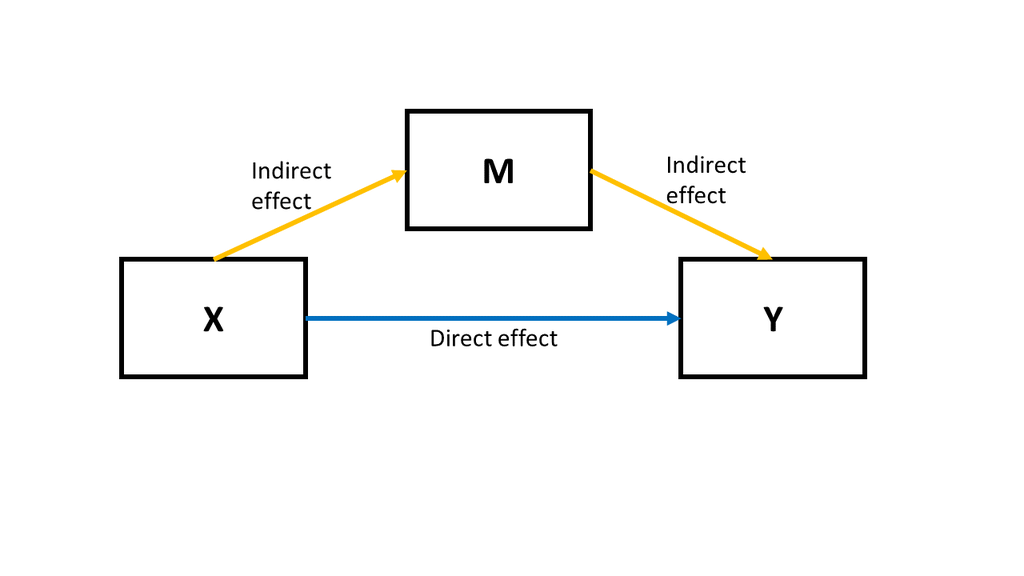

# Testing mediation

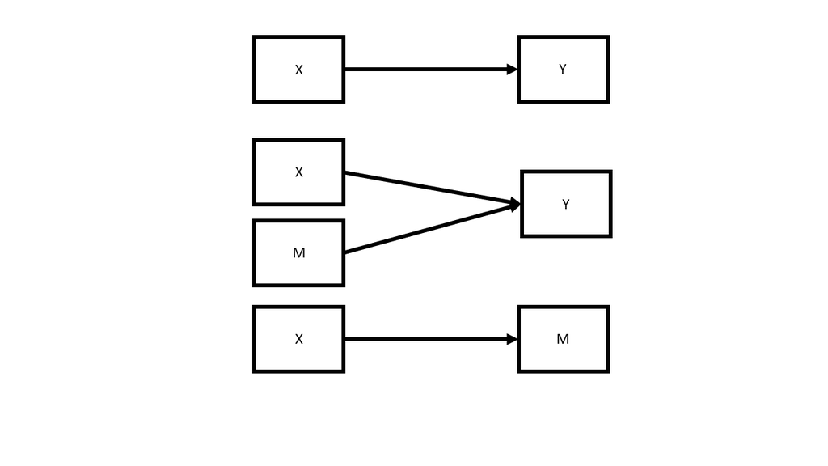

- Traditionally, mediation was tested using a series of separate regression models:
  1. Y~X
  2. Y~X+M
  3. M~X

# Traditional methods of testing mediation

- The three regression models:
  1. Y~X
  2. Y~X+M
  3. M~X
- Model 1 estimates the overall effect of X on Y
- Model 2 estimates the partial effects of X and M on Y
- Model 3 estimates the effect of X on M
- If the following conditions were met, mediation was assumed to hold:
  - The effect of X on Y (eq.1) is significant
  - The effect of X on M (eq.3) is significant
  - The effect of X on Y becomes reduced when M is added into the model (eq.2)

# Limitations of traditional methods of testing mediation

[figure not shown]

- Low power
- Very cumbersome for multiple mediators, predictors, or outcomes
- You don’t get an estimate of the magnitude of the indirect effect
- Much better way: **path mediation model**

# BREAK 1

- Time for a pause
- Quiz question:
  - Which of these hypotheses is a mediation hypothesis?
    - 1. Vocabulary development in childhood follows a non-linear trajecrtory
    - 2. The effects of conscientiousness on academic achievement are stronger at low levels of cognitive ability
    - 3. Poverty affects child behaviour problems through increasing parental stress
    - 4. Earlier pubertal onset increases the risk of antisocial behaviour only in girls and not boys

# WELCOME BACK 1

- Welcome back!
- The answer to the quiz question is…
  - Which of these hypotheses is a mediation hypothesis?
    - 1. Vocabulary development in childhood follows a non-linear trajecrtory
    - 2. The effects of conscientiousness on academic achievement are stronger at low levels of cognitive ability
    - 3. **Poverty affects child behaviour problems through increasing parental stress**
    - 4. Earlier pubertal onset increases the risk of antisocial behaviour only in girls and not boys

# Testing a path mediation model in lavaan

- Specification
  - Create a lavaan syntax object
- Estimation
  - Estimate the model using e.g., maximum likelihood estimation
- Evaluation/interpretation
  - Inspect the model to judge how good it is
  - Interpret the parameter estimates

# Example

[figure not shown]

- Does peer rejection mediate the association between aggression and depression?

[figure not shown]

# The data

```r
library(psych)
describe(agg.data2)
```

```
##     vars   n  mean   sd median trimmed  mad   min  max range  skew kurtosis
## Dep    1 500 -0.02 1.06   0.01   -0.03 1.10 -3.10 3.33  6.43  0.06    -0.02
## PR     2 500 -0.04 1.01  -0.06   -0.05 1.01 -3.28 2.80  6.09  0.05     0.03
## Agg    3 500  0.00 0.99  -0.03    0.01 0.91 -3.88 2.56  6.44 -0.18     0.23
##       se
## Dep 0.05
## PR  0.05
## Agg 0.04
```

```r
#PR = peer rejection, Agg= aggression, Dep= depression
```

# Mediation example

- Does peer rejection mediate the association between aggression and depression?

```r
#Create the model syntax

model1<-'Dep~PR      # Depression predicted by peer rejection
        Dep~Agg     # Depression predicted by aggression (the direct effect)
        PR~Agg      # Peer rejection predicted by aggression'


#estimate the model

model1.est<-sem(model1, data=agg.data2)
```

# The model output

```r
summary(model1.est, fit.measures=T)
```

```
## lavaan 0.6-5 ended normally after 12 iterations
##
##   Estimator                                         ML
##   Optimization method                           NLMINB
##   Number of free parameters                          5
##
##   Number of observations                           500
##
## Model Test User Model:
##
##   Test statistic                                 0.000
##   Degrees of freedom                                 0
##
## Model Test Baseline Model:
##
##   Test statistic                               221.854
##   Degrees of freedom                                 3
##   P-value                                        0.000
##
## User Model versus Baseline Model:
##
##   Comparative Fit Index (CFI)                    1.000
##   Tucker-Lewis Index (TLI)                       1.000
##
## Loglikelihood and Information Criteria:
##
##   Loglikelihood user model (H0)              -1343.461
##   Loglikelihood unrestricted model (H1)      -1343.461
##
##   Akaike (AIC)                                2696.923
##   Bayesian (BIC)                              2717.996
##   Sample-size adjusted Bayesian (BIC)         2702.125
##
## Root Mean Square Error of Approximation:
##
##   RMSEA                                          0.000
##   90 Percent confidence interval - lower         0.000
##   90 Percent confidence interval - upper         0.000
##   P-value RMSEA <= 0.05                             NA
##
## Standardized Root Mean Square Residual:
##
##   SRMR                                           0.000
##
## Parameter Estimates:
##
##   Information                                 Expected
##   Information saturated (h1) model          Structured
##   Standard errors                             Standard
##
## Regressions:
##                    Estimate  Std.Err  z-value  P(>|z|)
##   Dep ~
##     PR                0.319    0.046    6.925    0.000
##     Agg               0.250    0.047    5.294    0.000
##   PR ~
##     Agg               0.444    0.041   10.760    0.000
##
## Variances:
##                    Estimate  Std.Err  z-value  P(>|z|)
##    .Dep               0.887    0.056   15.811    0.000
##    .PR                0.834    0.053   15.811    0.000
```

# Things to note from the model output

- All three regressions paths are statistically significant
- The model is **just-identified**
  - The degrees of freedom are equal to 0
  - The model fit cannot be tested
  - The model fit statistics (TLI, CFI, RMSEA, SRMR) all suggest perfect fit but this is meaningless

# Visualising the model using semPaths()

- We can use semPaths() from the semPlot package to help us visualise the model
  - Shows the parameter estimates within an SEM diagram

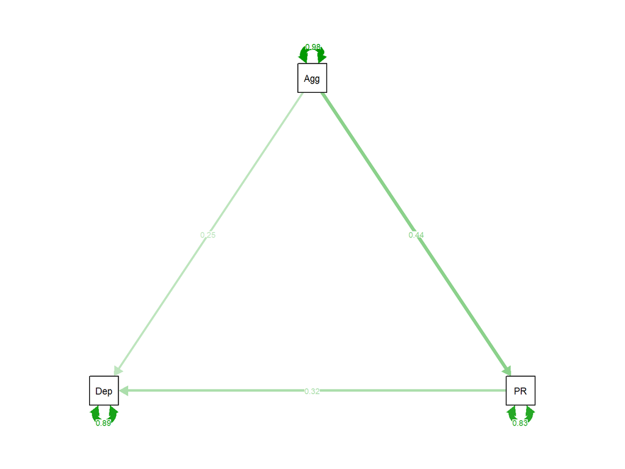

```r
library(semPlot)
semPaths(model1.est, what='est')
```

# Calculating the indirect effects

[figure not shown]

- To calculate the indirect effect of X on Y in path mediation, we need to create some new parameters
- The indirect effect of X on Y via M is:
  - $a*b$
  - $a$ = the regression coefficient for M~X
  - $b$ = the regression coefficient for Y~M

# Calculating indirect effects in lavaan

- To calculate the indirect effect of X on Y in lavaan we:
  - Use parameter labels ‘a’ and ‘b’ to label the relevant paths
    - a is for the effect of X on M
    - b is for the effect of M on Y
  - Use the ‘:=’ operator to create a new parameter ‘ind’
    - ‘ind’ represents our indirect effect

```r
  model1<-'Dep~b*PR     # Add b label here
           Dep~Agg
           PR~a*Agg     # Add a label here

ind:=a*b                # create a new parameter ind which is the product of a and b'
```

# Indirect effects in the output

```r
model1.est<-sem(model1, data=agg.data2)
summary(model1.est)
```

```
## lavaan 0.6-5 ended normally after 12 iterations
##
##   Estimator                                         ML
##   Optimization method                           NLMINB
##   Number of free parameters                          5
##
##   Number of observations                           500
##
## Model Test User Model:
##
##   Test statistic                                 0.000
##   Degrees of freedom                                 0
##
## Parameter Estimates:
##
##   Information                                 Expected
##   Information saturated (h1) model          Structured
##   Standard errors                             Standard
##
## Regressions:
##                    Estimate  Std.Err  z-value  P(>|z|)
##   Dep ~
##     PR         (b)    0.319    0.046    6.925    0.000
##     Agg               0.250    0.047    5.294    0.000
##   PR ~
##     Agg        (a)    0.444    0.041   10.760    0.000
##
## Variances:
##                    Estimate  Std.Err  z-value  P(>|z|)
##    .Dep               0.887    0.056   15.811    0.000
##    .PR                0.834    0.053   15.811    0.000
##
## Defined Parameters:
##                    Estimate  Std.Err  z-value  P(>|z|)
##     ind               0.142    0.024    5.823    0.000
```

# Statistical significance of the indirect effects

- Default method of assessing the statistical significance of indirect effects assume normal sampling distribution
- May not hold for indirect effects which are the product of regression coefficients
- Instead we can use **bootstrapping**
  - Provides an estimate of the sampling variance of a coefficient based on the actual data
    - as opposed to a theoretical sampling distribution
  - Resamples with replacement repeatedly from the observed data
  - Calculates the sampling variance based on variation of the coefficient across resamples
    - Number of resamples usually between 1000 and 10000
  - Allows 95% confidence intervals (CIs) to be computed
  - If 95% CI includes 0, the indirect effect is not significant at alpha=.05

# Bootstapped CIs for indirect effect in lavaan

```r
  model1<-'Dep~b*PR
           Dep~Agg
           PR~a*Agg
ind:=a*b'

model1.est<-sem(model1, data=agg.data2, se='bootstrap') #we add the argument se='bootstrap'
```

# Output for bootstrapped CIs for an indirect effect in lavaan

```r
summary(model1.est, ci=T) # we add the argument ci=T to see the confidence intervals in the output
```

```
## lavaan 0.6-5 ended normally after 12 iterations
##
##   Estimator                                         ML
##   Optimization method                           NLMINB
##   Number of free parameters                          5
##
##   Number of observations                           500
##
## Model Test User Model:
##
##   Test statistic                                 0.000
##   Degrees of freedom                                 0
##
## Parameter Estimates:
##
##   Standard errors                            Bootstrap
##   Number of requested bootstrap draws             1000
##   Number of successful bootstrap draws            1000
##
## Regressions:
##                    Estimate  Std.Err  z-value  P(>|z|) ci.lower ci.upper
##   Dep ~
##     PR         (b)    0.319    0.044    7.212    0.000    0.235    0.406
##     Agg               0.250    0.045    5.570    0.000    0.159    0.338
##   PR ~
##     Agg        (a)    0.444    0.045    9.821    0.000    0.352    0.533
##
## Variances:
##                    Estimate  Std.Err  z-value  P(>|z|) ci.lower ci.upper
##    .Dep               0.887    0.058   15.379    0.000    0.772    0.999
##    .PR                0.834    0.051   16.312    0.000    0.733    0.933
##
## Defined Parameters:
##                    Estimate  Std.Err  z-value  P(>|z|) ci.lower ci.upper
##     ind               0.142    0.024    5.922    0.000    0.097    0.193
```

# Total effects in path mediation

- As well as the direct and indirect effect, it is often of interest to know the **total** effect of X on Y
  $$Total = Indirect + Direct$$

# Total effects in path mediation

[figure not shown]

$$Total = a*b + c$$

# Total effect in lavaan

```r
  model1<-'Dep~b*PR
           Dep~c*Agg         # we add the label c for our direct effect
           PR~a*Agg
ind:=a*b
total:=a*b+c                 # we add a new parameter for the total effect'

model1.est<-sem(model1, data=agg.data2, se='bootstrap') #we add the argument se='bootstrap'
```

# Total effect in lavaan output

```r
summary(model1.est, ci=T)
```

```
## lavaan 0.6-5 ended normally after 12 iterations
##
##   Estimator                                         ML
##   Optimization method                           NLMINB
##   Number of free parameters                          5
##
##   Number of observations                           500
##
## Model Test User Model:
##
##   Test statistic                                 0.000
##   Degrees of freedom                                 0
##
## Parameter Estimates:
##
##   Standard errors                            Bootstrap
##   Number of requested bootstrap draws             1000
##   Number of successful bootstrap draws            1000
##
## Regressions:
##                    Estimate  Std.Err  z-value  P(>|z|) ci.lower ci.upper
##   Dep ~
##     PR         (b)    0.319    0.045    7.118    0.000    0.228    0.403
##     Agg        (c)    0.250    0.045    5.505    0.000    0.161    0.340
##   PR ~
##     Agg        (a)    0.444    0.044   10.012    0.000    0.359    0.529
##
## Variances:
##                    Estimate  Std.Err  z-value  P(>|z|) ci.lower ci.upper
##    .Dep               0.887    0.060   14.704    0.000    0.771    1.008
##    .PR                0.834    0.052   15.987    0.000    0.735    0.938
##
## Defined Parameters:
##                    Estimate  Std.Err  z-value  P(>|z|) ci.lower ci.upper
##     ind               0.142    0.024    5.827    0.000    0.095    0.193
##     total             0.392    0.043    9.204    0.000    0.309    0.475
```

# Why code the total effect in lavaan?

- We could have just added up the coefficients for the direct and indirect effects
- By coding it in lavaan, however, we can assess the statistical significance of the total effect
- Useful because sometimes the direct and indirect effects are not individually significant but the total effect is
  - May be especially relevant in cases where there are many mediators of small effect

# Interpreting the total, direct, and indirect effect coefficients

- The total effect can be interpreted as the *unit increase in Y expected to occur when X increases by one unit*
- The indirect effect can be interpreted as the *unit increase in Y expected to occur via M when X increases by one unit*
- The direct effect can be interpreted as the *unit increase in Y expected to occur with a unit increase in X over and above the increase transmitted by M*
  - Note: ‘direct’ effect may not actually be direct - it may be acting via other mediators not included in our model

# Standardised parameters

- As with CFA models, standardised parameters can be obtained using:

```r
summary(model1.est, ci=T, standardized=T)
```

```
## lavaan 0.6-5 ended normally after 12 iterations
##
##   Estimator                                         ML
##   Optimization method                           NLMINB
##   Number of free parameters                          5
##
##   Number of observations                           500
##
## Model Test User Model:
##
##   Test statistic                                 0.000
##   Degrees of freedom                                 0
##
## Parameter Estimates:
##
##   Standard errors                            Bootstrap
##   Number of requested bootstrap draws             1000
##   Number of successful bootstrap draws            1000
##
## Regressions:
##                    Estimate  Std.Err  z-value  P(>|z|) ci.lower ci.upper
##   Dep ~
##     PR         (b)    0.319    0.045    7.118    0.000    0.228    0.403
##     Agg        (c)    0.250    0.045    5.505    0.000    0.161    0.340
##   PR ~
##     Agg        (a)    0.444    0.044   10.012    0.000    0.359    0.529
##    Std.lv  Std.all
##
##     0.319    0.306
##     0.250    0.234
##
##     0.444    0.434
##
## Variances:
##                    Estimate  Std.Err  z-value  P(>|z|) ci.lower ci.upper
##    .Dep               0.887    0.060   14.704    0.000    0.771    1.008
##    .PR                0.834    0.052   15.987    0.000    0.735    0.938
##    Std.lv  Std.all
##     0.887    0.790
##     0.834    0.812
##
## Defined Parameters:
##                    Estimate  Std.Err  z-value  P(>|z|) ci.lower ci.upper
##     ind               0.142    0.024    5.827    0.000    0.095    0.193
##     total             0.392    0.043    9.204    0.000    0.309    0.475
##    Std.lv  Std.all
##     0.142    0.132
##     0.392    0.366
```

# BREAK 2

- Time for a pause
- Quiz question
  - If the effect of X on M is b=.30 and the effect of M on Y is b=.10, what is the indirect effect of X on Y?
    - 1. b=.40
    - 2. b=.03
    - 3. b=.30
    - 4. b=.10

# Welcome back 2

- Welcome back!
- The answer to the quiz question is…
- Quiz question
  - If the effect of X on M is b=.30 and the effect of M on Y is b=.10, what is the indirect effect of X on Y?
    - 1. b=.40
    - 2. **b=.03**
    - 3. b=.30
    - 4. b=.10

# Reporting path mediation models

- Methods
  - The model being tested
  - e.g. ‘Y was regressed on both X and M and M was regressed on X’
  - The estimator used (e.g., maximum likelihood estimation)
  - The method used to test the significance of indirect effects (‘bootstrapped 95% confidence intervals’)
- Results
  - Model fit (for over-identified models)
  - The parameter estimates for the path mediation and their statistical significance
    - Can be useful to present these in a SEM diagram
    - The diagrams from R not considered ‘publication quality’ - draw in powerpoint or similar

# Reporting path mediation models - example of SEM diagram with results

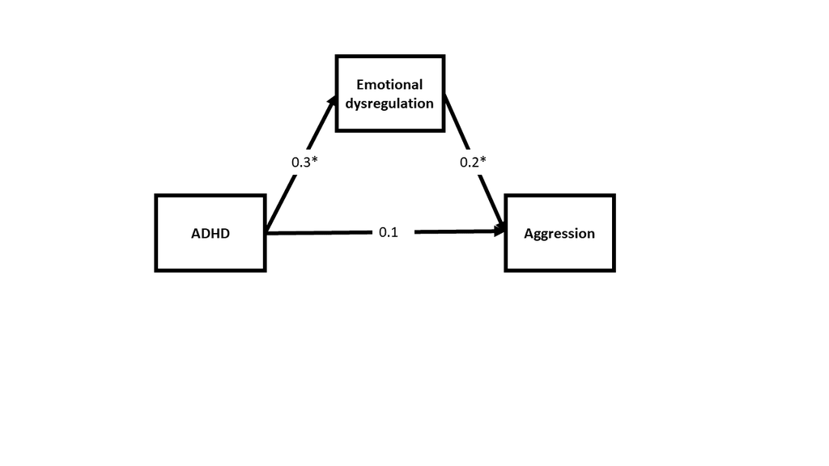

Note. *=significant at p<.05

- Include the key parameter estimates
- Indicate statistically significant paths (e.g. with an ’*’)
- Include a figure note that explains how statistically significant paths (and at what level) are signified

# Reporting path mediation models - the indirect effects

- Results
  - The coefficient for the indirect effect and the bootstrapped 95% confidence intervals
  - Common to also report **proportion mediation**:

  $$\frac{indirect}{total}$$
- However, important to be aware of limitations:
  - Big proportion mediation possible when total effect is small - makes effect seem more impressive
  - Small proportion mediation even when total effect is big - can underplay importance of effect
  - Should be interpreted in context of total effect
- Tricky interpretation if there are a mix of negative and positive effects involved

# Extensions of path mediation models

- We can extend our path mediation model in various ways:
  - Several mediators in sequence or parallel
  - Multiple outcomes
  - Multiple predictors
  - Multiple groups (e.g., comparing direct and indirect effects across males and females)
  - Add covariates to adjust for potential confounders

# Example: multiple mediation model

[figure not shown]

```r
model2<-'Dep~b2*Aca
         Aca~a2*Agg

         Dep~b1*PR
         PR~a1*Agg

         Dep~c*Agg  # direct effect

ind1:=a1*b1
ind2:=a2*b2
total=a1*b1+a2*b2+c'
```

# Other path analysis models

- Path mediation models are a common application of path models
- But they are just one example
- Anything that can be expressed in terms of regressions between observed variables can be tested as a path model
- Can include ordinal or binary variables
- Can include moderation
- Other common path analysis models include:
  - Autoregressive models for longitudinal data
  - Cross-lagged panel models for longitudinal data

# Other path analysis models - AR

- autoregressive models to examine the stability of a construct over time

[figure not shown]

```r
##creating a lavaan syntax object for an autoregressive model

Autoregressive<-'AggT3~AggT2
                 AggT2~AggT1'
```

# Other path analysis models - CLPM

- cross-lagged panel models to examine the relations between constructs over time
  - autoregressive paths control for previous levels of each construct
  - cross-lagged paths capture the relations between the two constructs

[figure not shown]

```r
# creating a lavaan syntax object for a CLPM
CLPM<-'AggT3~AggT2+DepT2
       AggT2~AggT1+DepT1
       DepT3~DepT2+AggT2
       DepT2~DepT1+AggT1'
```

# Other path analysis models - CLPM with mediation

- longitudinal mediation models using a cross-lagged panel model

[figure not shown]

```r
#creating a lavaan syntax object for a longitudinal mediation model

CLPM.med<-'AggT3~AggT2+DepT2+PRT2
           AggT2~AggT1+DepT1+PRT1
           DepT3~DepT2+AggT2+b*PRT2   # label the effect of M on Y as b
           DepT2~DepT1+AggT1+PRT1
           PRT3~PRT2+AggT2+DepT2
           PRT2~PRT1+a*AggT1+DepT1    # label the effect of X on M as a

ind:=a*b'
```

# Making model modifications

- As in CFA models, you *may* want to make some modifications to your initially hypothesised model
  - non-significant paths that you want to trim
  - include some additional paths not initially included
- Remember that this now moves us into exploratory territory where:
  - Model modifications should be substantively as well as statistically justifiable
  - You must be aware of the possibility that you are capitalising on chance
  - You should aim to replicate the modifications in independent data

# Cautions regarding path analysis models

- **Assumption** that the paths represent causal effects is only an assumption
  - Especially if using cross-sectional data
- The parameters are only accurate if the model is correctly specified

# Cautions regarding path analysis models - indistinguishable models

[figure not shown]

# Measurement error in path analysis

- Path analysis models use observed variables
- Assumes no measurement error in these variables
- Path coefficients likely to be attenuated due to unmodelled measurement error
- Structural equation models solve this issue
- They are path analysis models where the paths are between latent rather than observed variables
- …more on this next week

# Path analysis summary

- Path analysis can be used to fit sets of regression models
  - Common path analysis model is the path mediation model
  - But very flexible - huge range of models that can be tested
- In R, path analysis can be done using the sem( ) function in lavaan
- Need to be aware that we aren’t *testing* causality but assuming it